# MECH476: Engineering Data Analysis in R

Chapter 7 Homework: Multivariate Exploratory Data Analysis

Genevieve Reyland-Slawson

08 November, 2023

# Load packages

```r
# load packages for current session
library(tidyverse)
library(ggplot2)
library(gridExtra)
salaries_path <- "/Users/genevieve/Reyland-MECH476/data/ME_Salaries.csv"
```

# Chapter 7 Homework

In [Chapter 5](https://smogdr.github.io/edar_coursebook/eda1.html#cumulative-distribution-plot), we briefly explored data on the salaries of engineering graduates from the National Science Foundation 2017 [National Survey of College Graduates](https://www.nsf.gov/statistics/srvygrads/) from a univariate perspective. Now, let’s explore the relationships between multiple variables.

When a question asks you to make a plot, remember to set a theme, title, subtitle, labels, colors, etc. It is up to you how to personalize your plots, but put in some effort, and make the plotting approach consistent throughout the document. For example, you could use the same theme for all plots. I also like to use the subtitle as a place for the main summary for the viewer.

## Question 1: Data wrangling

Within a pipeline, import the data from the .csv file, convert all column names to lowercase text (either “manually” with `dplyr::rename()`, or use [`clean_names()` from the `janitor` package](https://rdrr.io/cran/janitor/man/clean_names.html)), convert `gender` from “numeric” to “factor”, and drop any and all observations with `salary` recorded as 0. Assign this to a dataframe object with a meaningful name.

```r
# import and tidy salary data
salaries <- readr::read_csv(file = salaries_path)
names(salaries) <- tolower(names(salaries))

salaries$gender <- as.factor(salaries$gender)
important_data <- salaries %>%
  dplyr::filter(salary > 0)
```

How many observations have a 0 (zero) value for salary? Note: The last question asked you to remove these observations from the resultant data frame.

–> there were 15 observations that had a 0 for salary.

```r
# number of observations with salary as 0
zero_salary <- salaries %>%
  dplyr::filter(salary == 0) %>%
  tally()
```

What are the levels in `gender`? (Ignore the fact that the observations refer to “biological sex”, not “gender”. *Gender* is now recognized as a fluid term with more than two options; *biological sex* - what was assigned at birth - is binary term).

–> “F” and “M”

```r
# number of factor levels
levels(salaries$gender)
```

```
## [1] "F" "M"
```

## Question 2: Univariate EDA

Using what you learned in Chapter 5, generate basic plots and/or descriptive statistics to explore `age`, `gender`, and `salary`. List whether each variable is continuous or categorical, and explain how and why you adjusted your EDA approach accordingly.

## Question 3: Multivariate histograms

Create a histogram of `salary`, faceted by `gender`. Add `bins = 50` and `color = "lightgrey"`.

[figure not shown]

```r
# histogram of salaries split by gender
hist_salary <- ggplot(data = salaries) +
  geom_histogram(aes(x = salary),
                 bins = 50,
                 color = "lightgrey") +
  labs(x = "Salary",
       y = "Number of People",
       title = "Histogram of Salaries Based on Age",
       subtitle = "Engineering Graduates Salaries Split by Age") +
  scale_x_continuous(labels = scales::label_dollar(scale = 0.001,
                                                   prefix = '$',
                                                   suffix = 'k'))

# faceted by gender
hist_salary + facet_grid(cols = vars(gender),
                         labeller = label_both)
```

Create a histogram of `age`, faceted by `gender`. Add `bins = 50` and `color = "lightgrey"`.

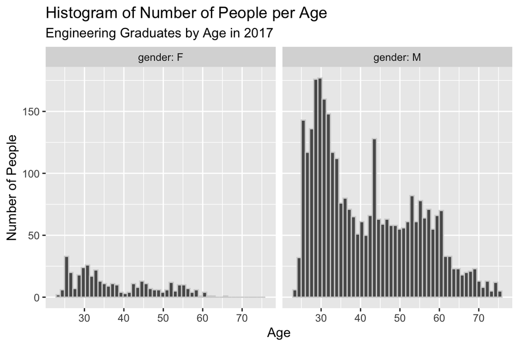

```r
# histogram of ages split by gender
hist_age2 <- ggplot(data = salaries) +
  geom_histogram(aes(x = age),
                 bins = 50,
                 color = "lightgrey") +
  labs(x = "Age",
       y = "Number of People",
       title = "Histogram of Number of People per Age",
       subtitle = "Engineering Graduates by Age in 2017")
hist_age2 + facet_grid(cols = vars(gender),
                       labeller = label_both)
```

## Question 4: Multivariate boxplots

Create a boxplot of `salary`, faceted by `gender`. Use `oulier.shope = 1` to better visualize the outliers.

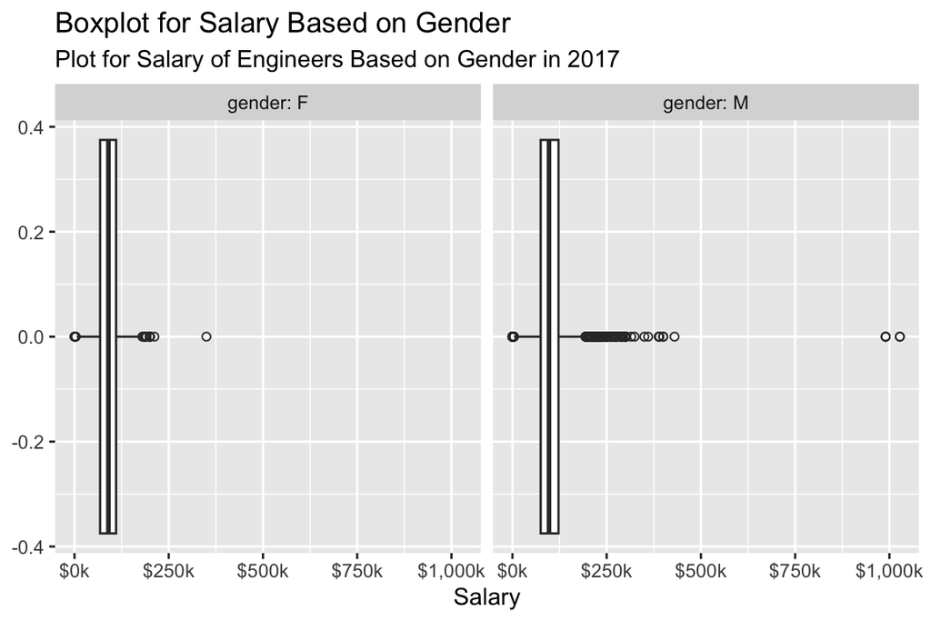

```r
# boxplots of salary data by gender
salary_box <- ggplot(data = salaries) +
  geom_boxplot(aes(y = salary),
               outlier.shape = 1) +
  labs(y = "Salary",
       title = "Boxplot for Salary Based on Gender",
       subtitle = "Plot for Salary of Engineers Based on Gender in 2017") +
  scale_y_continuous(labels = scales::label_dollar(scale = 0.001,
                                                   prefix = '$',
                                                   suffix = 'k')) +
  coord_flip()
salary_box + facet_grid(cols = vars(gender),
                        labeller = label_both)
```

Create a boxplot of `age`, faceted by `gender`.

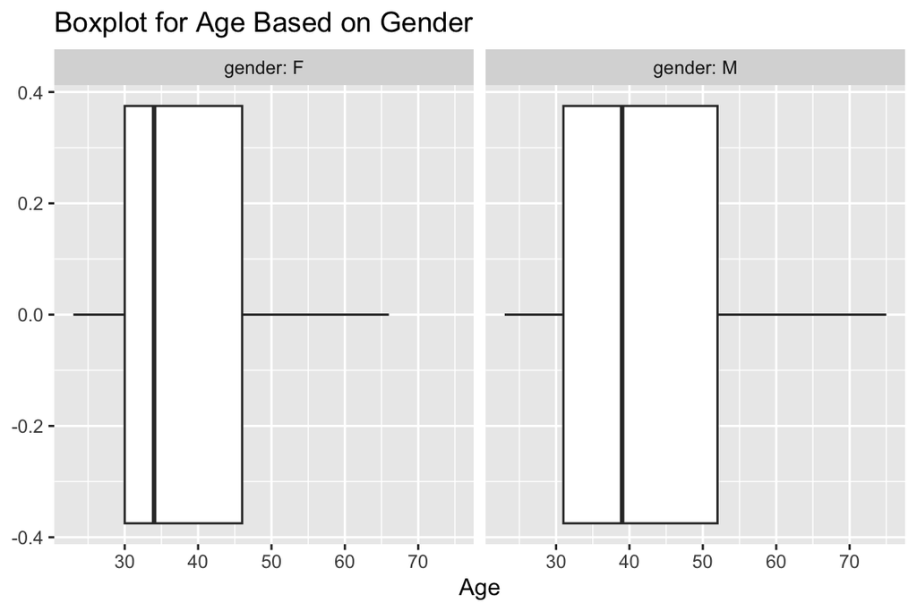

```r
# boxplots of age data by gender
age_box <- ggplot(data = salaries) +
  geom_boxplot(aes(y = age)) +
  labs(y = "Age",
       title = "Boxplot for Age Based on Gender") +
  coord_flip()
age_box + facet_grid(cols = vars(gender),
                        labeller = label_both)
```

## Question 5: Scatterplot and correlation

Create a scatterplot of `age` (x-axis) and `salary`, differentiating by `gender`.

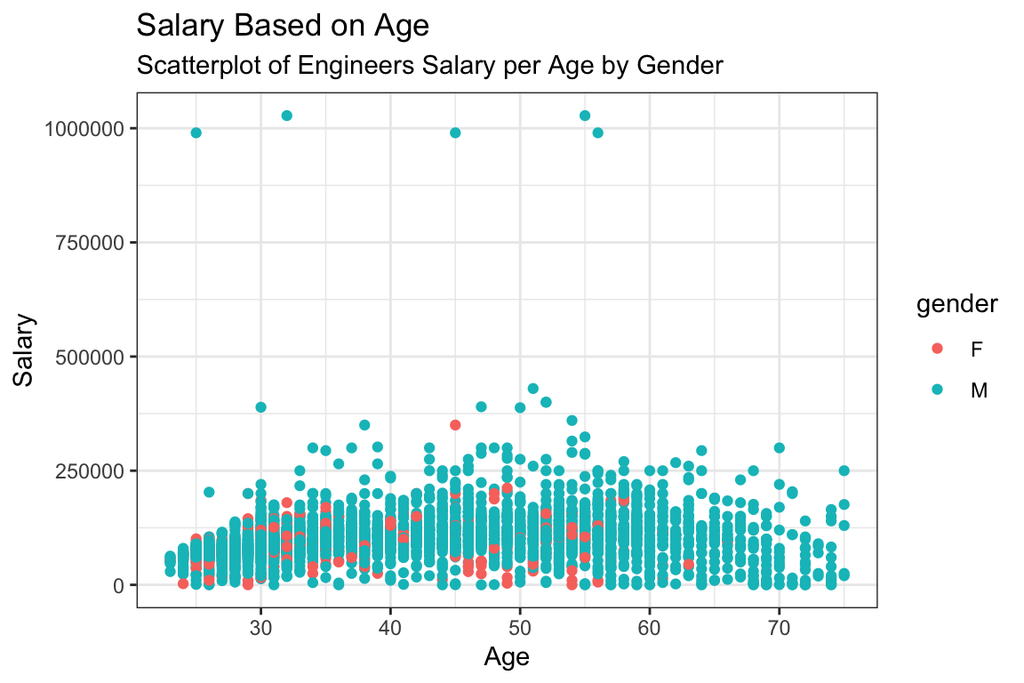

```r
# scatterplot of salary across age by gender
multivar_scatter <- ggplot(data = salaries,
                           mapping = aes(x = age,
                                         y = salary,
                                         color = gender)) +
  geom_point() +
  labs(x = "Age",
       y = "Salary",
       title = "Salary Based on Age",
       subtitle = "Scatterplot of Engineers Salary per Age by Gender") +
  theme_bw()
multivar_scatter
```

*Bonus point*: Is there a correlation between an engineer’s salary and age? What is the estimated Pearson correlation coefficient *r*? Run a formal test.

–> 0.1969265 which means there’s not a high correlation.

```r
# correlation test
corr_test <- cor(salaries$salary, salaries$age)
```

## Question 6: Cumulative distribution function

Plot the cumulative distribution function of `salary` by `gender`. Adjust the x-axis with `scale_x_log10(limits = c(5e4, 5e5))` to zoom in a bit. What do you notice about the salaries for men and women? Hint: Remember there are greater differences the farther up you go on a log scale axis.

–> For the women in the highest quantile, they are making less than the men in the highest quantile. This is a similar pattern in all the quantiles where men are making more than women in the same quantile.

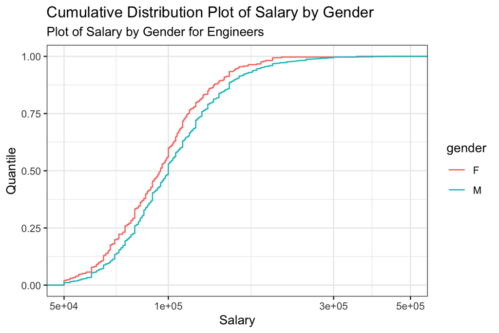

```r
# plot cdf of salary by gender
salary_ecdf <- ggplot(data = salaries) +
  geom_step(aes(x = salary,
                color = gender),
            stat = "ecdf") +
  labs(x = "Salary",
       y = "Quantile",
       title = "Cumulative Distribution Plot of Salary by Gender",
       subtitle = "Plot of Salary by Gender for Engineers") +
  scale_x_log10(limits = c(5e4, 5e5)) +
  theme_bw()
salary_ecdf
```

## Question 7: Quantiles

Calculate the quantiles of `salary` by `gender`. You can either subset the data with `dplyr::filter()` and dataframe assignment, or you can group by, summarize by quantile, and ungroup.

*Bonus point*: Assign the output to a dataframe, and use inline code to call individual values when answering the following questions. Do not let R use scientific notation in the text output; check the knitted document.

```r
# calculate quantiles of salary by gender
set.seed(1)

f_quart <- salaries %>%
  dplyr::select(salary, gender) %>%
  dplyr::group_by(gender) %>%
  dplyr::filter(gender == "F") %>%
  dplyr::ungroup()

m_quart <- salaries %>%
  dplyr::select(salary, gender) %>%
  dplyr::group_by(gender) %>%
  dplyr::filter(gender == "M") %>%
  dplyr::ungroup()

m_cdf_salaries <- quantile(m_quart$salary, probs = seq(0, 1, 0.25))
f_cdf_salaries <- quantile(f_quart$salary, probs = seq(0, 1, 0.25))

m_cdf_salaries
```

```
##        0%       25%       50%       75%      100%
##       0.0   75000.0   97000.0  122280.8 1027653.0
```

```r
f_cdf_salaries
```

```
##       0%      25%      50%      75%     100%
##      0.0  68000.0  90000.0 110384.8 350000.0
```

```r
paste0("The median salary for women is ", "$", median(f_cdf_salaries))
```

```
## [1] "The median salary for women is $90000"
```

```r
paste0("The median salary for men is ", "$", median(m_cdf_salaries))
```

```
## [1] "The median salary for men is $97000"
```

```r
paste0("The difference at the median is ", "$", median(m_cdf_salaries) - median(f_cdf_salaries))
```

```
## [1] "The difference at the median is $7000"
```

```r
paste0("The max salary for women is ", "$", max(f_cdf_salaries))
```

```
## [1] "The max salary for women is $350000"
```

```r
paste0("The max salary for men is ", "$", max(m_cdf_salaries))
```

```
## [1] "The max salary for men is $1027653"
```

```r
paste0("The difference at the maximum is ", "$", max(m_cdf_salaries) - max(f_cdf_salaries))
```

```
## [1] "The difference at the maximum is $677653"
```

What is the difference in salary between men and women at the median?

- Median salary for women is $90,000
- Median salary for men is $97,000
- The difference at the median is $7,000

At the top percentile (maximum)?

Do you think there is a salary difference by gender across the pay scale? What other information would you need to test your hypothesis?

## Question 8: Hypothetical analysis

Think about what other variables you would like to include in an hypothetical analysis. From your perspective, what are the most important individual, family, and workforce factors related to salary—beyond gender and age?

–> I would look at the specific occupation of the people, if they went into the industry, research, or something else not related to engineering. The other charts created allow to see that in the quantiles men are making more than women. I think it could be interesting to see if mean make more than women at each age though. I think it could be interesting to also see how long each person had been working as well to see if age and time correlate to salary. In addition, another interesting factor could be location, people in California and New York most likely make more than engineers in Idaho or Missouri.

## Question 9: Recreate plot

Recreate this plot with the `mpg` dataset. Remember to use `?mpg` for information on the dataset and the variables. How would you describe the correlation between the independent variable and dependent variable? Do you see any patterns when considering the third variable?

(View R Markdown PDF for image)

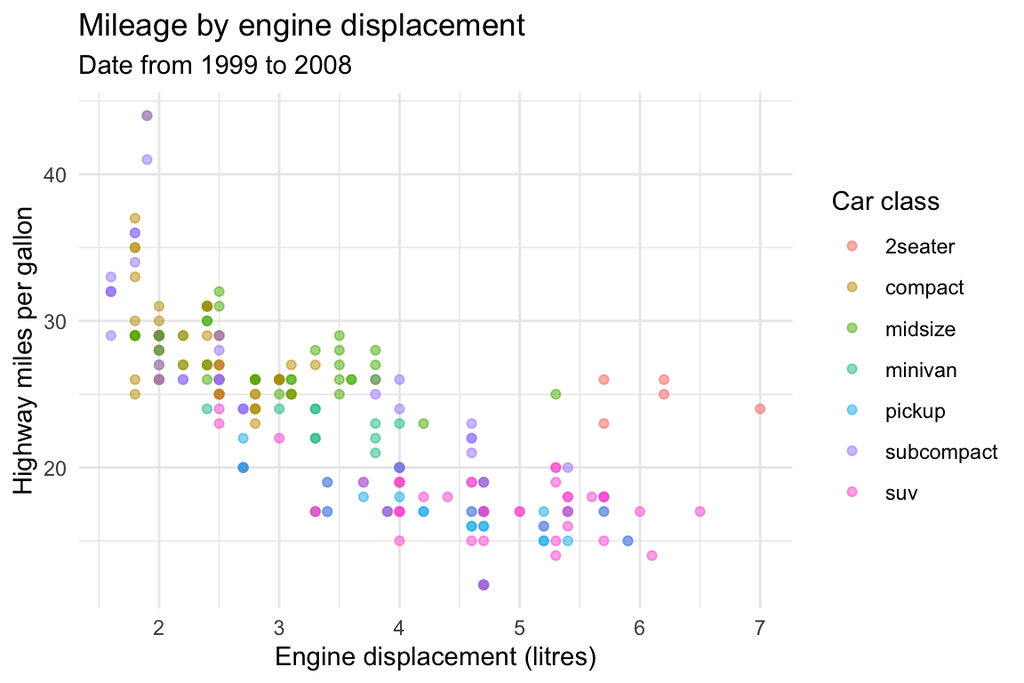

```r
# call mpg pdf - you need to recreate it
mpg_plot <- ggplot(data = mpg) +
  geom_point(aes(x = displ,
                 y = hwy,
                 color = class),
             alpha = 0.5) +
  labs(x = "Engine displacement (litres)",
       y = "Highway miles per gallon",
       title = "Mileage by engine displacement",
       subtitle = "Date from 1999 to 2008",
       color = "Car class") +
  theme_minimal()
mpg_plot
```

```r
image_mpg <- "/Users/genevieve/Reyland-MECH476/data/images/mpg-ch7-plot.pdf"
knitr::include_graphics(image_mpg)
```

[figure not shown]

# Appendix

```r
# set global options for figures, code, warnings, and messages
knitr::opts_chunk$set(fig.width=6, fig.height=4, fig.path="../figs/",
                      echo=TRUE, warning=FALSE, message=FALSE)
# load packages for current session
library(tidyverse)
library(ggplot2)
library(gridExtra)
salaries_path <- "/Users/genevieve/Reyland-MECH476/data/ME_Salaries.csv"
# import and tidy salary data
salaries <- readr::read_csv(file = salaries_path)
names(salaries) <- tolower(names(salaries))

salaries$gender <- as.factor(salaries$gender)
important_data <- salaries %>%
  dplyr::filter(salary > 0)

# number of observations with salary as 0
zero_salary <- salaries %>%
  dplyr::filter(salary == 0) %>%
  tally()
# number of factor levels
levels(salaries$gender)
# univariate eda
# cumulative bar chart for gender and age
g_plot <- ggplot(data = salaries,
                 mapping = aes(x = age,
                               y = salary,
                               fill = gender)) +
  geom_bar(stat = "identity",
           position = "dodge")

# box plot for age vs salary
box_salary <- ggplot(data = salaries,
                     mapping = aes(x = salary,
                                   fill = gender,
                                   y = gender)) +
  geom_boxplot(outlier.alpha = 0.05) +
  theme_bw()

# quartile plot for gender and salary
quartile_salary <- ggplot(data = salaries,
                          mapping = aes(x = salary,
                                        color = gender)) +
  stat_ecdf() +
  theme_bw() +
  labs(x = "Salary",
       y = "Quantile")

# histogram of gender vs age
hist_age <- ggplot(data = salaries) +
  geom_histogram(aes(x = age,
                     fill = gender),
                 bins = 100,
                 position = "dodge")

# embed plots into one figure
gridExtra::grid.arrange(g_plot, box_salary, quartile_salary, hist_age,
                        widths = c(0.4, 1, 0.4),
                        layout_matrix = rbind(c(NA, 1, NA),
                                              c(NA, 2, NA),
                                              c(NA, 3, NA),
                                              c(NA, 4, NA)))
# histogram of salaries split by gender
hist_salary <- ggplot(data = salaries) +
  geom_histogram(aes(x = salary),
                 bins = 50,
                 color = "lightgrey") +
  labs(x = "Salary",
       y = "Number of People",
       title = "Histogram of Salaries Based on Age",
       subtitle = "Engineering Graduates Salaries Split by Age") +
  scale_x_continuous(labels = scales::label_dollar(scale = 0.001,
                                                   prefix = '$',
                                                   suffix = 'k'))

# faceted by gender
hist_salary + facet_grid(cols = vars(gender),
                         labeller = label_both)
# histogram of ages split by gender
hist_age2 <- ggplot(data = salaries) +
  geom_histogram(aes(x = age),
                 bins = 50,
                 color = "lightgrey") +
  labs(x = "Age",
       y = "Number of People",
       title = "Histogram of Number of People per Age",
       subtitle = "Engineering Graduates by Age in 2017")
hist_age2 + facet_grid(cols = vars(gender),
                       labeller = label_both)
# boxplots of salary data by gender
salary_box <- ggplot(data = salaries) +
  geom_boxplot(aes(y = salary),
               outlier.shape = 1) +
  labs(y = "Salary",
       title = "Boxplot for Salary Based on Gender",
       subtitle = "Plot for Salary of Engineers Based on Gender in 2017") +
  scale_y_continuous(labels = scales::label_dollar(scale = 0.001,
                                                   prefix = '$',
                                                   suffix = 'k')) +
  coord_flip()
salary_box + facet_grid(cols = vars(gender),
                        labeller = label_both)
# boxplots of age data by gender
age_box <- ggplot(data = salaries) +
  geom_boxplot(aes(y = age)) +
  labs(y = "Age",
       title = "Boxplot for Age Based on Gender") +
  coord_flip()
age_box + facet_grid(cols = vars(gender),
                        labeller = label_both)
# scatterplot of salary across age by gender
multivar_scatter <- ggplot(data = salaries,
                           mapping = aes(x = age,
                                         y = salary,
                                         color = gender)) +
  geom_point() +
  labs(x = "Age",
       y = "Salary",
       title = "Salary Based on Age",
       subtitle = "Scatterplot of Engineers Salary per Age by Gender") +
  theme_bw()
multivar_scatter
# correlation test
corr_test <- cor(salaries$salary, salaries$age)
# plot cdf of salary by gender
salary_ecdf <- ggplot(data = salaries) +
  geom_step(aes(x = salary,
                color = gender),
            stat = "ecdf") +
  labs(x = "Salary",
       y = "Quantile",
       title = "Cumulative Distribution Plot of Salary by Gender",
       subtitle = "Plot of Salary by Gender for Engineers") +
  scale_x_log10(limits = c(5e4, 5e5)) +
  theme_bw()
salary_ecdf
# calculate quantiles of salary by gender
set.seed(1)

f_quart <- salaries %>%
  dplyr::select(salary, gender) %>%
  dplyr::group_by(gender) %>%
  dplyr::filter(gender == "F") %>%
  dplyr::ungroup()

m_quart <- salaries %>%
  dplyr::select(salary, gender) %>%
  dplyr::group_by(gender) %>%
  dplyr::filter(gender == "M") %>%
  dplyr::ungroup()

m_cdf_salaries <- quantile(m_quart$salary, probs = seq(0, 1, 0.25))
f_cdf_salaries <- quantile(f_quart$salary, probs = seq(0, 1, 0.25))

m_cdf_salaries
f_cdf_salaries

paste0("The median salary for women is ", "$", median(f_cdf_salaries))
paste0("The median salary for men is ", "$", median(m_cdf_salaries))
paste0("The difference at the median is ", "$", median(m_cdf_salaries) - median(f_cdf_salaries))

paste0("The max salary for women is ", "$", max(f_cdf_salaries))
paste0("The max salary for men is ", "$", max(m_cdf_salaries))
paste0("The difference at the maximum is ", "$", max(m_cdf_salaries) - max(f_cdf_salaries))
# call mpg pdf - you need to recreate it
mpg_plot <- ggplot(data = mpg) +
  geom_point(aes(x = displ,
                 y = hwy,
                 color = class),
             alpha = 0.5) +
  labs(x = "Engine displacement (litres)",
       y = "Highway miles per gallon",
       title = "Mileage by engine displacement",
       subtitle = "Date from 1999 to 2008",
       color = "Car class") +
  theme_minimal()
mpg_plot

image_mpg <- "/Users/genevieve/Reyland-MECH476/data/images/mpg-ch7-plot.pdf"
knitr::include_graphics(image_mpg)
```